# 1. Descriptive Statistics

Descriptive statistics refer to methods for summarizing raw observations into information that we can understand and share. Commonly, we think of descriptive statistics as the calculation of statistical values from the data in order to summarize properties of the data, such as the common expected value (e.g. the mean or median) and the spread of the data (e.g. the variance or standard deviation). Descriptive statistics may also cover graphical methods that can be used to visualize samples of data. Charts and graphics can provide a useful qualitative understanding of both the shape or distribution of observations as well as how variables may relate to each other.

# 1.1. Measures of Central Tendency

Measures of central tendency give us an idea about the concentration of the values in the central part of the distribution. Plainly speaking, an average of a data is the value of the variable which is representative of the entire distribution. The central tendency of a distribution refers to the middle or the most common or most likely value in the distribution.

## Mean

This is a simple arithmetic average, which is computed by taking the aggregated sum of values divided by a count of those values.

$$ \frac{X_1 + X_2 + ... + X_N}{N} = {1 \over N} \sum\limits_{i = 1}^{N} X_i$$

When our observations constitute an entire population, the mean is denoted by $\mu$, and when our data constitute a sample, mean is denoted by $\bar{X}$.

Mean of a population,

$$ \mu = {1 \over N} \sum\limits_{i = 1}^{N} X_i $$

Mean of a sample,

$$ \bar{X} = {1 \over n} \sum\limits_{i = 1}^{n} X_i $$

**Arithmetic mean is affected very much by extreme values.** The mean is sensitive to outliers in the data. An outlier is the value of a set or column that is highly deviant from the many other values in the same data; it usually has very high or low values. Thus, in case of extreme items, arithmetic mean gives a distorted picture of the distribution and no longer remains representative of the distribution.

**Frequency Distribution:** Frequency in statistics is the count of the occurrences of values within a particular group or interval. A frequency distribution displays the frquencies either in a graphical or tabular format. Many of the times, frequency distribution is simply called **distribution**.

```python
xi = [4,5,1,2,7,2,6,9,3]
```

```python
#Calculating Mean

xbar =  sum(xi)/len(xi)

print("Mean:",xbar)
```

```
Mean: 4.333333333333333
```

An easier way is to use the buit-in library of python called `statistics`.

```python
import statistics as stat
stat.mean(xi)
```

```
4.333333333333333
```

You can also call the specific function to be used from the library

```python
from statistics import mean
mean(xi)
```

```
4.333333333333333
```

## Median

Median of a distribution is the value of the variable which divides it into two equal parts. It is the value such that the number of observations above it is equal to the number of observations below it. The median is thus a *positional average* and is the midpoint of the data.

If the number of observations is odd then median is the middle value after the values have been arranged in ascending or descending order of magnitude. In case of even number of observations, there are two middle terms and median is obtained by taking the arithmetic mean of the middle terms.

**Median is not affected by extreme values.**

```python
xi = [4,5,1,2,7,2,6,9,3]
```

```python
from statistics import median
median(xi)
```

```
4
```

## Mode

Mode is the value which occurs most frequently in the data set or we can say this is the most repetitive data point in the data.

```python
from statistics import mode
mode(xi)
```

```
2
```

```python
#Calculating Mode

import collections

ctr = collections.Counter(xi)
print("Frequency of the elements in the List : ",ctr)
```

```
Frequency of the elements in the List :  Counter({2: 2, 4: 1, 5: 1, 1: 1, 7: 1, 6: 1, 9: 1, 3: 1})
```

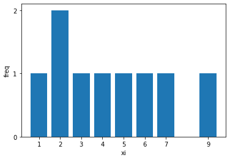

```python
#finding mode graphically

import numpy as np
import matplotlib.pyplot as plt

x = list(ctr.keys())
freq = list(ctr.values())

plt.bar(x,freq)
plt.xticks(x)
plt.yticks(np.arange(3))
plt.xlabel('xi')
plt.ylabel('freq')
plt.show()
```

**Mean is the best measure of central tendency when:**

The distribution of data is continuous and symmetrical, such as when your data is normally distributed (you will be introduced to Normal Distributions later in the course). However, it all depends on what you are trying to show from your data.

**Median is the best measure of central tendency when:**

The data set is skewed (i.e., forms a **non symmetric** distribution) or you are dealing with ordinal data. However, the mode can also be appropriate in these situations, but **IS NOT** as commonly used as the median.

**Mode is the best measure of central tendency when:**

The data is of Nominal type. However, mode is the least used of the measures of central tendency.

**The mean and/or median are usually preferred when dealing with all other types of data, but this does not mean it is never used with these data types.**

The Python code for the calculation of mean, median, and mode using a numpy array and the stats package is as follows:

```python
import numpy as np

data = np.array([4,5,1,2,7,2,6,9,3])
```

```python
# Calculate Mean
dt_mean = np.mean(data)
print ("Mean :",round(dt_mean,2))
```

```
Mean : 4.33
```

```python
# Calculate Median
dt_median = np.median(data)
print ("Median :",dt_median)
```

```
Median : 4.0
```

```python
# Calculate Mode
from scipy import stats

dt_mode =  stats.mode(data)
print ("Mode :",dt_mode[0][0])
```

```
Mode : 2
```

- We have used a NumPy array instead of a basic list as the data structure; the reason behind using this is the scikit-learn package built on top of NumPy array in which all statistical models and machine learning algorithms have been built on NumPy array itself.
- The mode function is not implemented in the numpy package, hence we have used SciPy's stats package. SciPy is also built on top of NumPy arrays.

Let's see how it works for a Matrix.

```python
import numpy as np

# Mean in case of a 2D Array or Matrix
mat = np.array([[4,5,1,2,7],[2,6,9,3,1],[3,1,2,1,1]])

print('Matrix :\n',mat)

mat_mean = np.mean(mat)  #mean of all elements in the matrix
col_mean = np.mean(mat,axis=0)  #mean for each columns in the matrix
row_mean = np.mean(mat,axis=1)  #mean for each rows in the matrix

print('\nMean of all elements:',mat_mean)
print('\nMean along columns',col_mean)
print('\nMean along rows',row_mean)
```

```
Matrix :
 [[4 5 1 2 7]
 [2 6 9 3 1]
 [3 1 2 1 1]]

Mean of all elements: 3.2

Mean along columns [3. 4. 4. 2. 3.]

Mean along rows [3.8 4.2 1.6]
```

Lets see how to obtain the three averages from a Pandas dataframe.

```python
import pandas as pd
import numpy as np
```

```python
# Let's build a data set
df = pd.DataFrame([
 { 'name': 'Smushface', 'salary': 12000,'degree': 'BS'} ,
 { 'name': 'Jen', 'salary': 25000,'degree': 'BS' },
 { 'name': 'James', 'salary': 55000,'degree': 'MS' },
 { 'name': 'Ross', 'salary': 35000,'degree': 'MS' },
 { 'name': 'Tyler', 'salary': 25000,'degree': 'BS' },
 { 'name': 'Jacques', 'salary': 15000,'degree': 'BS' },
 { 'name': 'Gates', 'salary': 100000,'degree': 'PhD' },
 { 'name': 'Peter', 'salary': 30000,'degree': 'MS' },
 { 'name': 'Adam', 'salary': 25000,'degree': 'MS' },
 { 'name': 'Brian', 'salary': 20000,'degree': 'BS' }
])
df
```

|  | name | salary | degree |
| --- | --- | --- | --- |
| 0 | Smushface | 12000 | BS |
| 1 | Jen | 25000 | BS |
| 2 | James | 55000 | MS |
| 3 | Ross | 35000 | MS |
| 4 | Tyler | 25000 | BS |
| 5 | Jacques | 15000 | BS |
| 6 | Gates | 100000 | PhD |
| 7 | Peter | 30000 | MS |
| 8 | Adam | 25000 | MS |
| 9 | Brian | 20000 | BS |

```python
mean_sal = df['salary'].mean()
print("Mean Salary = ",mean_sal)
```

```
Mean Salary =  34200.0
```

```python
df['salary'].sort_values()
median_sal = df['salary'].median()
print("Median Salary = ",median_sal)
```

```
Median Salary =  25000.0
```

```python
mode_sal = df['salary'].mode()[0]
print("Mode Salary = ",mode_sal)
```

```
Mode Salary =  25000
```

```
[(0.0, 120000.0)]
```

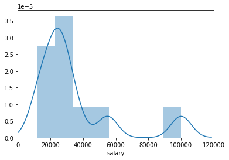

```python
import matplotlib.pyplot as plt
import seaborn as sns
%matplotlib inline

grp = sns.distplot(df['salary'])
grp.set(xlim=(0,120000))
```

## Measures of Central Tendency & Shape of a distribution

If a data set or population is symmetric (i.e., if one side of the distribution of the observations is a mirror image of the other) and if the distribution of the observations has only one mode, then the mode, the median, and the mean are all equal i.e., $Mean = Median = Mode$.

In other words, Mean, Median and Mode coincide in case of a symmetrical distribution. However, for a moderately asymmetrical distribution, mean and mode usually lie on the two ends and median lies in between them.

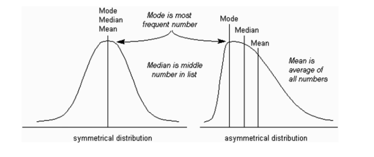

As a demonstration of this, lets play with our dataframe and see how the changes happen in our distribution.

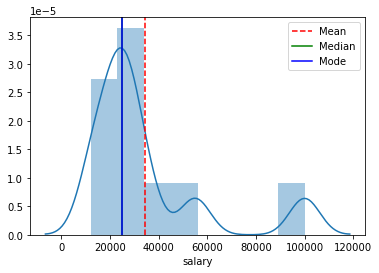

```python
import matplotlib.pyplot as plt
import seaborn as sns
%matplotlib inline

sns.distplot(df["salary"])
plt.axvline(mean_sal, color='r', linestyle='--')
plt.axvline(median_sal, color='g', linestyle='-')
plt.axvline(mode_sal, color='b', linestyle='-')

plt.legend({'Mean':mean_sal,'Median':median_sal,'Mode':mode_sal})
plt.show()
```

As an experiment we will remove data related to `'Gates'`.

```python
df2 = df[df['name'] != 'Gates']
print(df2)
```

```
        name  salary degree
0  Smushface   12000     BS
1        Jen   25000     BS
2      James   55000     MS
3       Ross   35000     MS
4      Tyler   25000     BS
5    Jacques   15000     BS
7      Peter   30000     MS
8       Adam   25000     MS
9      Brian   20000     BS
```

```python
mean_sal2 = df2['salary'].mean()
median_sal2 = df2['salary'].median()
mode_sal2 = df2['salary'].mode()[0]
```

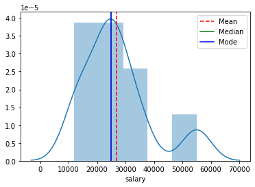

```python
import matplotlib.pyplot as plt
import seaborn as sns
%matplotlib inline

sns.distplot(df2["salary"])
plt.axvline(mean_sal2, color='r', linestyle='--')
plt.axvline(median_sal2, color='g', linestyle='-')
plt.axvline(mode_sal2, color='b', linestyle='-')

plt.legend({'Mean':mean_sal2,'Median':median_sal2,'Mode':mode_sal2})
plt.show()
```

Let's remove one more person `'James'` from out data set.

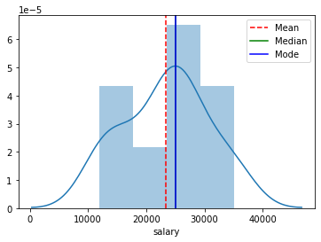

```python
df3 = df[(df['name'] != 'Gates') & (df['name'] != 'James')]
# print(df3)

mean_sal3 = df3['salary'].mean()
median_sal3 = df3['salary'].median()
mode_sal3 = df3['salary'].mode()[0]

import matplotlib.pyplot as plt
import seaborn as sns
%matplotlib inline


sns.distplot(df3["salary"])
plt.axvline(mean_sal3, color='r', linestyle='--')
plt.axvline(median_sal3, color='g', linestyle='-')
plt.axvline(mode_sal3, color='b', linestyle='-')

plt.legend({'Mean':mean_sal3,'Median':median_sal3,'Mode':mode_sal3})
plt.show()
```

You can clearly observe the change in distribution and also the unstability of Mean as extreme values changes.

**Que:** Find the mean salary of employees having a 'BS' degree.

```python
df[df.degree == 'BS'].mean()
```

```
salary    19400.0
dtype: float64
```

## Multimodal distribution

Data distributions in statistics can have one peak, or they can have several peaks. The **bimodal distribution has two peaks** and Multimodal distribution have more than 2 peaks.

The “bi” in bimodal distribution refers to “two” and modal refers to the peaks. It can seem a little confusing because in statistics, the term “mode” refers to the most common number. However, if you think about it, The two peaks in a bimodal distribution also represent two local maximums; these are points where the data points stop increasing and start decreasing.

**If you’ve got two peaks of data, it usually indicates you’ve got two different groups**.

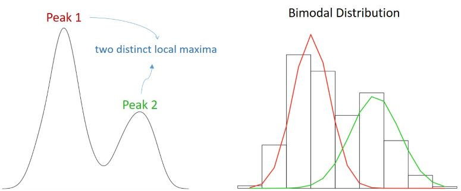

```python
import pandas as pd
import matplotlib.pyplot as plt
import seaborn as sns
```

```python
# read the csv file
df = pd.read_csv('./weight-height.csv')

# print the first 5 rows of the data set
df
```

|  | Gender | Height | Weight |
| --- | --- | --- | --- |
| 0 | Male | 73.847017 | 241.893563 |
| 1 | Male | 68.781904 | 162.310473 |
| 2 | Male | 74.110105 | 212.740856 |
| 3 | Male | 71.730978 | 220.042470 |
| 4 | Male | 69.881796 | 206.349801 |
| ... | ... | ... | ... |
| 9995 | Female | 66.172652 | 136.777454 |
| 9996 | Female | 67.067155 | 170.867906 |
| 9997 | Female | 63.867992 | 128.475319 |
| 9998 | Female | 69.034243 | 163.852461 |
| 9999 | Female | 61.944246 | 113.649103 |

10000 rows × 3 columns

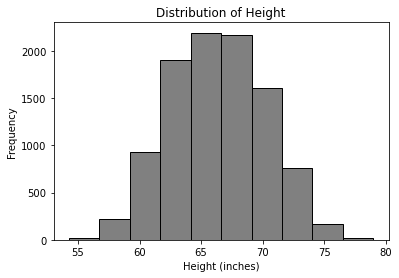

```python
# histogram of the height

# df.Height.plot(kind='hist', color='grey')
df.Height.plot(kind='hist', color='grey',edgecolor = "black")
plt.title('Distribution of Height')
plt.xlabel('Height (inches)')
plt.ylabel('Frequency')
plt.show()
```

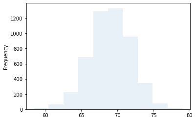

```python
df[df['Gender'] == 'Male'].Height.plot(kind = 'hist',alpha = 0.1)
```

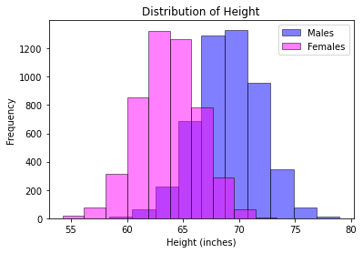

```python
# histogram of the Height - males and females

df[df['Gender'] == 'Male'].Height.plot(kind='hist', color='blue', edgecolor='black', alpha=0.5)
df[df['Gender'] == 'Female'].Height.plot(kind='hist', color='magenta', edgecolor='black', alpha=0.5)
plt.legend(labels=['Males', 'Females'])
plt.title('Distribution of Height')
plt.xlabel('Height (inches)')
plt.ylabel('Frequency')
```

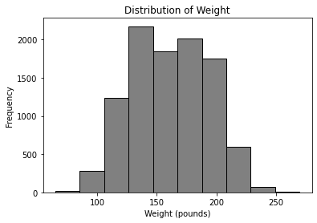

```python
# histogram of the weight

# df.Weight.plot(kind='hist', color='grey')
df.Weight.plot(kind='hist', color='grey',edgecolor = "black")
plt.title('Distribution of Weight')
plt.xlabel('Weight (pounds)')
plt.ylabel('Frequency')
plt.show()
```

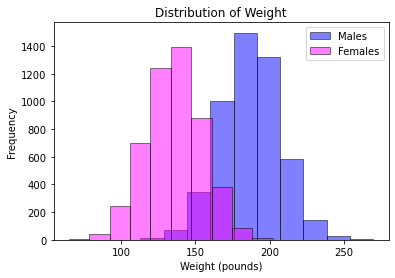

```python
# histogram of the weight - males and females

df[df['Gender'] == 'Male'].Weight.plot(kind='hist', color='blue', edgecolor='black', alpha=0.5)
df[df['Gender'] == 'Female'].Weight.plot(kind='hist', color='magenta', edgecolor='black', alpha=0.5)
plt.legend(labels=['Males', 'Females'])
plt.title('Distribution of Weight')
plt.xlabel('Weight (pounds)')
plt.ylabel('Frequency')
```